# R Notebook

# 3.3 Aesthetic mapping

- An aesthetic is a visual property of the objects in your plot

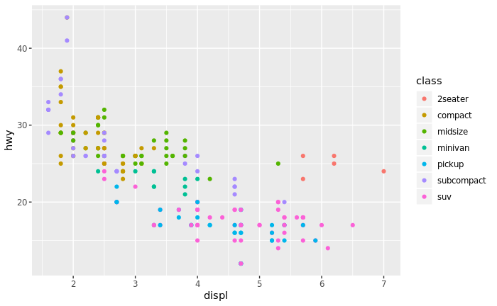

```r
ggplot(data = mpg) +
  geom_point(mapping = aes(x = displ, y = hwy, color = class))
```

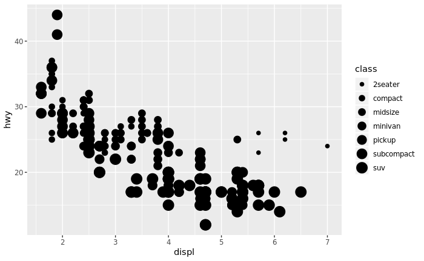

```r
ggplot(data = mpg) +
  geom_point(mapping = aes(x = displ, y = hwy, size = class))
```

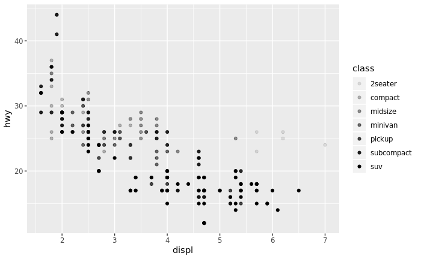

```r
# Left
ggplot(data = mpg) +
  geom_point(mapping = aes(x = displ, y = hwy, alpha = class))
```

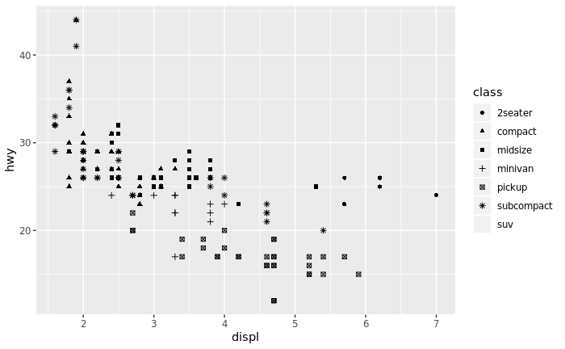

```r
# Right
ggplot(data = mpg) +
  geom_point(mapping = aes(x = displ, y = hwy, shape = class))
```

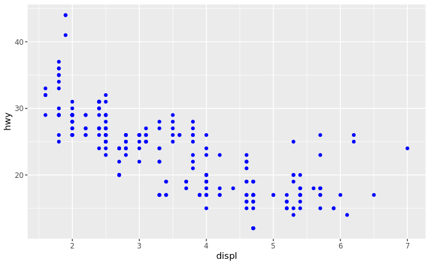

```r
ggplot(data = mpg) +
  geom_point(mapping = aes(x = displ, y = hwy), color = "blue")
```

- To set an aesthetic manually, set the aesthetic by name as an argument of your geom function
- The name of a color as a character string.
- The size of a point in mm.
- The shape of a point as a number

### 3.3.1 Exercises

1). The points are not blue because the command of color has to be outside of the aes()

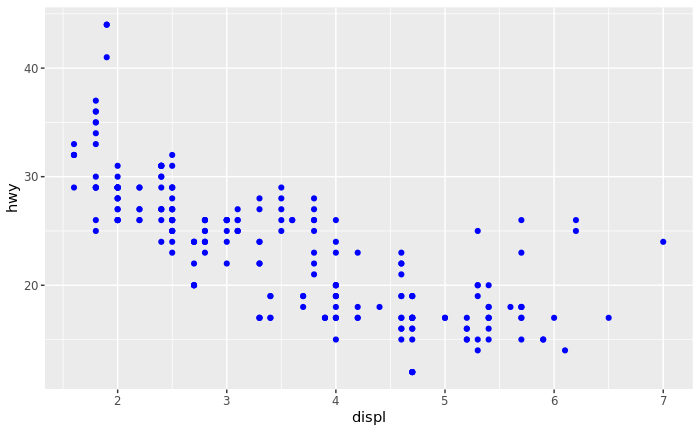

```r
ggplot(data = mpg) +
  geom_point(mapping = aes(x = displ, y = hwy), color = "blue")
```

2).

- Categorical: model, trans, drv, fl, class
- Continous: displ, year, cyl, cty, hwy

3).

```r
ggplot(mpg, aes(x = displ, y = hwy, color = cty)) +
  geom_point()
ggplot(mpg, aes(x = displ, y = hwy, size = cty)) +
  geom_point()
ggplot(mpg, aes(x = displ, y = hwy, shape = cty)) +
  geom_point()
```

[output not shown]

4).

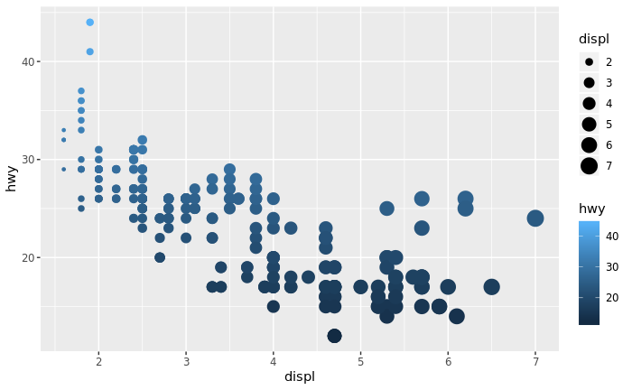

```r
ggplot(mpg, aes(x = displ, y = hwy, colour = hwy, size = displ)) +
  geom_point()
```

5). Stroke changes the size of the border for shapes.

6).The color of the plot is temporarly blue until it hits the 5 mark on the graph then it changes color

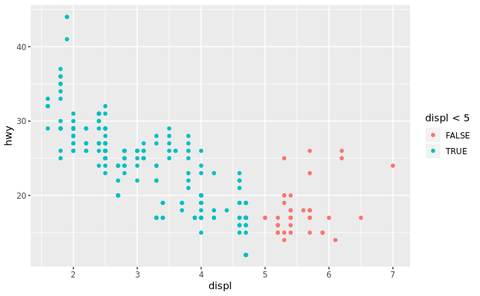

```r
ggplot(mpg, aes(x = displ, y = hwy, colour = displ < 5)) +
  geom_point()
```

# 3.4 Common problems

- R is extremely picky, and a misplaced character can make all the difference.
- Make sure that every ( is matched with a ) and every " is paired with another "

# 3.5 Facets

1).subplots graph variables in a large scale individualy 2).The empty cells have no observations because in this plot are combinations of drv and cyl

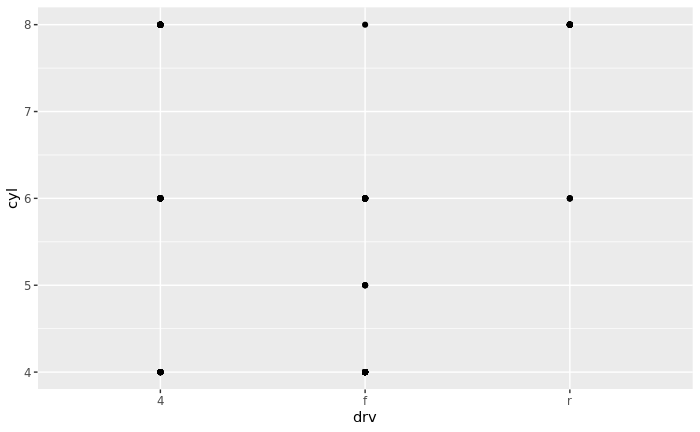

```r
ggplot(data = mpg) +
  geom_point(mapping = aes(x = drv, y = cyl))
```

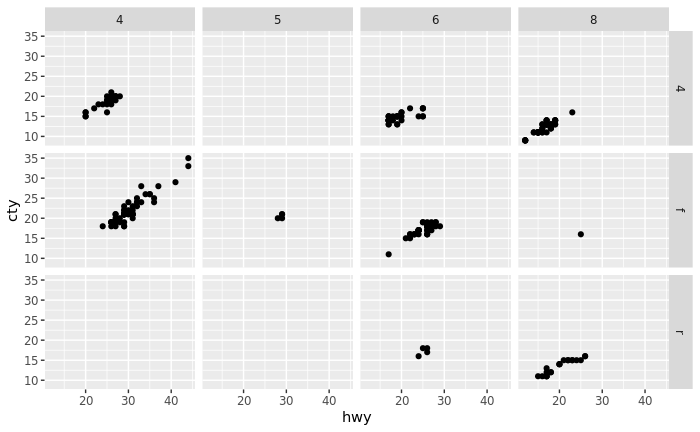

```r
ggplot(data = mpg) +
  geom_point(mapping = aes(x = hwy, y = cty)) +
  facet_grid(drv ~ cyl)
```

3).The symbol . ignores the dimension when faceting.

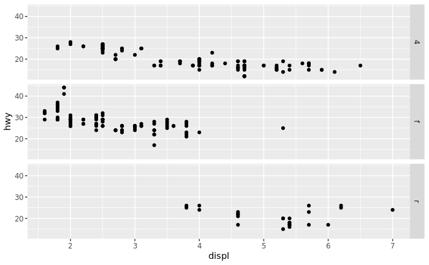

```r
ggplot(data = mpg) +
  geom_point(mapping = aes(x = displ, y = hwy)) +
  facet_grid(drv ~ .)
```

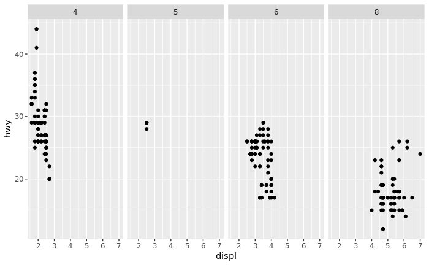

```r
ggplot(data = mpg) +
  geom_point(mapping = aes(x = displ, y = hwy)) +
  facet_grid(. ~ cyl)
```

4).Advantages of encoding class with facets is the ability to encode more clear categories. Disadvantages of encoding the class variable with facets is the difficulty of comparing the values of observations between categories Because the observations for each category are on different plots.

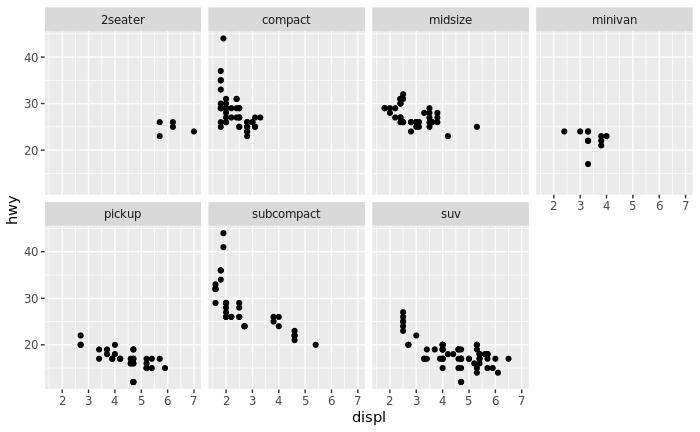

```r
ggplot(data = mpg) +
  geom_point(mapping = aes(x = displ, y = hwy)) +
  facet_wrap(~ class, nrow = 2)
```

5). nrow (ncol) determines the number of rows that should be used when laying out the facets. It is necessary since facet_wrap() only facets on one variable.nrow and ncol are unnecessary for facet_grid() because of unique values of the variables determines the number of rows and columns.

6).If it is laid out horizontally there will be more space for columns

# 3.6 Geometric objects

- A geom is the geometrical object that a plot uses to represent data.
- To change the geom in your plot, change the geom function that you add to ggplot()
- not every aesthetic works with every geom
- Many geoms, like geom_smooth(), use a single geometric object to display multiple rows of data.
- If you place mappings in a geom function, ggplot2 will treat them as local mappings for the layer.

### 3.6.1 exercise

1).

- line chart: geom_line()
- boxplot: geom_boxplot()
- histogram: geom_histogram()
- area chart: geom_area()

2).This code makes a scatter plot it has displ on the x-axis, hwy on the y-axis, and the points colored by drv

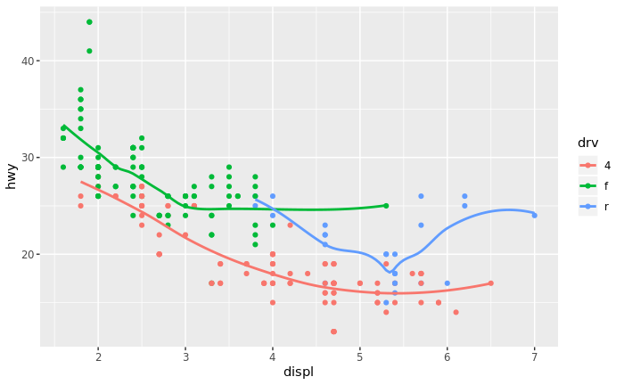

```r
ggplot(data = mpg, mapping = aes(x = displ, y = hwy, color = drv)) +
  geom_point() +
  geom_smooth(se = FALSE)
```

3). show.legend = FALSE hides the legend. It was hidden to make the documents more aesthetically pleasing.

4). adds standard error bands to the lines.

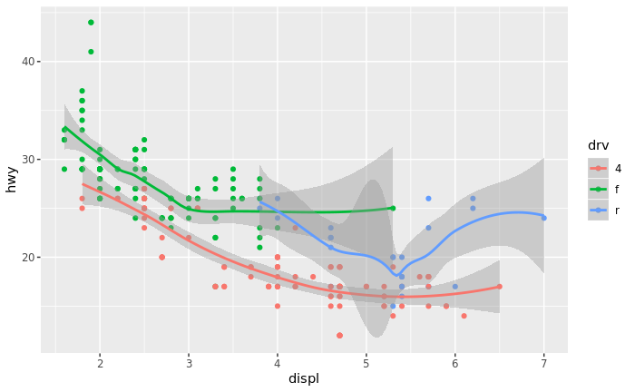

```r
ggplot(data = mpg, mapping = aes(x = displ, y = hwy, colour = drv)) +
  geom_point() +
  geom_smooth(se = TRUE)
```

5). no they will use the same data and mappings

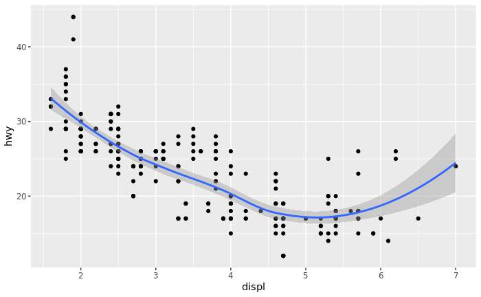

```r
ggplot(data = mpg, mapping = aes(x = displ, y = hwy)) +
  geom_point() +
  geom_smooth()
```

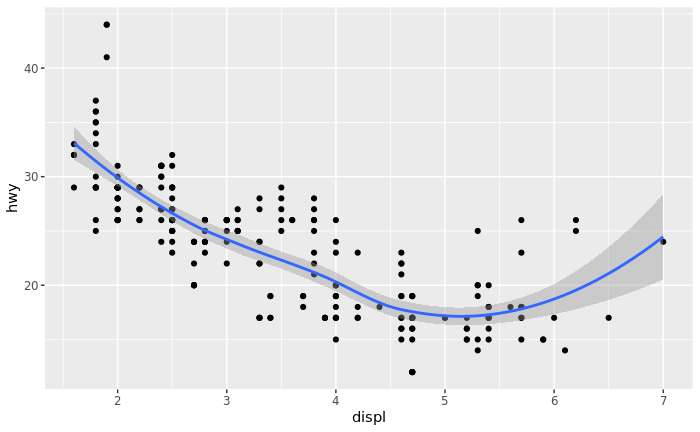

```r
ggplot() +
  geom_point(data = mpg, mapping = aes(x = displ, y = hwy)) +
  geom_smooth(data = mpg, mapping = aes(x = displ, y = hwy))
```

6).

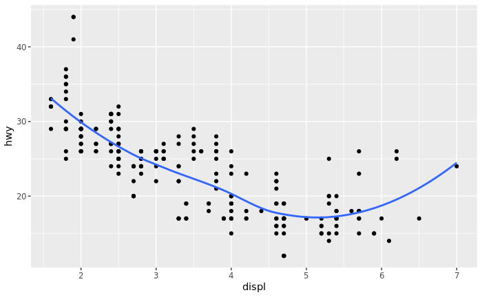

```r
ggplot(mpg, aes(x = displ, y = hwy)) +
  geom_point() +
  geom_smooth(se = FALSE)
```

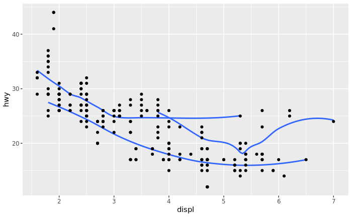

```r
ggplot(mpg, aes(x = displ, y = hwy)) +
  geom_smooth(mapping = aes(group = drv), se = FALSE) +
  geom_point()
```

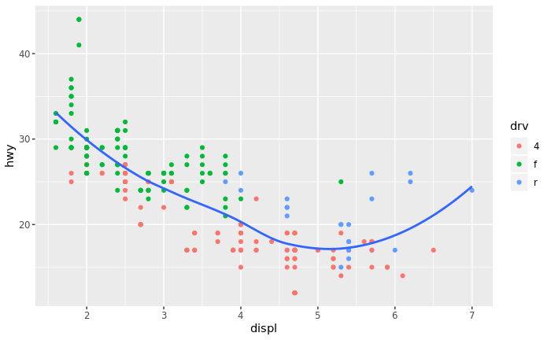

```r
ggplot(mpg, aes(x = displ, y = hwy)) +
  geom_point(aes(colour = drv)) +
  geom_smooth(se = FALSE)
```

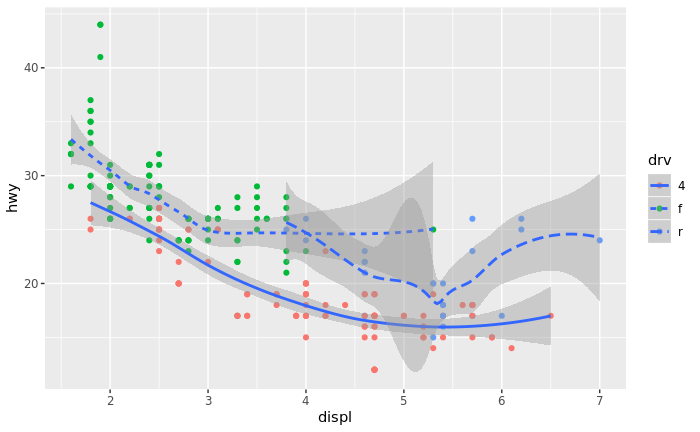

```r
ggplot(mpg, aes(x = displ, y = hwy)) +
  geom_point(aes(colour = drv)) +
  geom_smooth(aes(linetype = drv), se = TRUE)
```

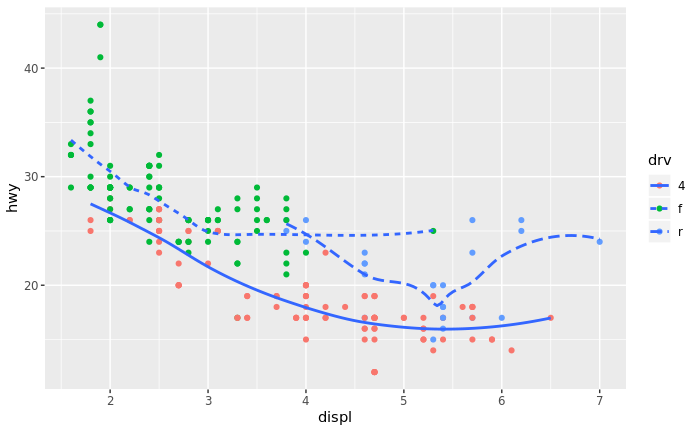

```r
ggplot(mpg, aes(x = displ, y = hwy)) +
  geom_point(aes(colour = drv)) +
  geom_smooth(aes(linetype = drv), se = FALSE)
```

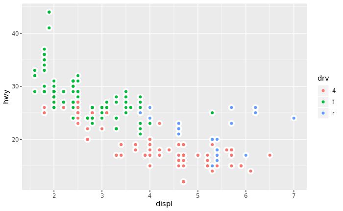

```r
ggplot(mpg, aes(x = displ, y = hwy)) +
  geom_point(size = 4, color = "white") +
  geom_point(aes(colour = drv))
```

# 3.7 Statistical transformations

- Other graphs, like bar charts, calculate new values to plot:
- bar charts, histograms, and frequency polygons bin your data and then plot bin counts, the number of points that fall in each bin.
- smoothers fit a model to your data and then plot predictions from the model.
- boxplots compute a robust summary of the distribution and then display a specially formatted box.

#### 3.7.1 Exercises

1). stat_summary() uses the mean and sd to calculate the middle point and endpoints of the line.

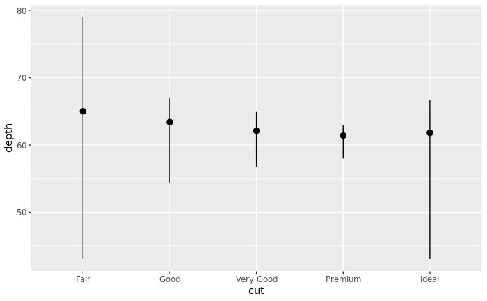

```r
ggplot(data = diamonds) +
  geom_pointrange(
    mapping = aes(x = cut, y = depth),
    stat = "summary",
    fun.ymin = min,
    fun.ymax = max,
    fun.y = median
  )
```

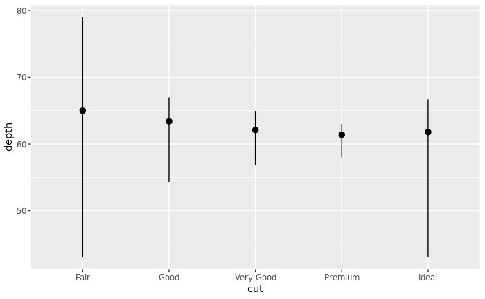

```r
ggplot(data = diamonds) +
  stat_summary(
    mapping = aes(x = cut, y = depth),
    fun.ymin = min,
    fun.ymax = max,
    fun.y = median
  )
```

2).

- The geom_col() function has different default stat than geom_bar()
- function expects that the data contains x values and y values which represent the bar height
- The stat, stat_bin(), preprocesses input data by counting the number of observations for each value of x.

3).

4).

stats_smooth(): - y: predicted value - ymin: lower value of the confidence interval - ymax: upper value of the confidence interval - se: standard error

parameters: - formula: the formula are parameters such as method which determines which method is used to calculate the predictions and confidence interval - na.rm - methods